# Hw 5

Andrew Maloney

4/9/2019

# Part 1

The code below downloads the data for Ames only and saves a local copy to your machine. The first time you run this code, make sure you have a good internet connection and enough space on your machine (~50 MB). If the local copy exists, re-knitting the file will load the (binary) file from disk and be much faster.

```r
if(file.exists("alcohol.rds")) {
  data <- readRDS("alcohol.rds")
} else {
  url <- "https://xdaiisu.github.io/ds202materials/data/ames.csv"
  data <- readr::read_csv(url)
  saveRDS(data, file = "alcohol.rds")

}
```

```r
library(dplyr)
library(tidyverse)
library(stringr)
```

# Part 2 Data Cleaning

1. Extract geographic latitude and longitude from the variable Store Location

```r
data_clean_1 <- data %>% separate(`Store Location`, c("address1", "address2", "coords"), sep = "\n") %>% select(-address1, -address2) %>% mutate(coords = gsub("[()]", "", coords)) %>% separate(coords, c("lat", "long"), sep = ",") # My code
str(data_clean_1)
```

```
## Classes 'tbl_df', 'tbl' and 'data.frame':    382033 obs. of  25 variables:
##  $ Invoice/Item Number  : chr  "INV-15386000001" "INV-15386000002" "INV-15386200001" "INV-15386600001" ...
##  $ Date                 : chr  "10/31/2018" "10/31/2018" "10/31/2018" "10/31/2018" ...
##  $ Store Number         : num  4129 4129 4129 4129 3524 ...
##  $ Store Name           : chr  "Cyclone Liquors" "Cyclone Liquors" "Cyclone Liquors" "Cyclone Liquors" ...
##  $ Address              : chr  "626 Lincoln Way" "626 Lincoln Way" "626 Lincoln Way" "626 Lincoln Way" ...
##  $ City                 : chr  "Ames" "Ames" "Ames" "Ames" ...
##  $ Zip Code             : num  50010 50010 50010 50010 50010 ...
##  $ lat                  : chr  "42.022854" "42.022854" "42.022854" "42.022854" ...
##  $ long                 : chr  " -93.618911" " -93.618911" " -93.618911" " -93.618911" ...
##  $ County Number        : num  85 85 85 85 85 85 85 85 85 85 ...
##  $ County               : chr  "STORY" "STORY" "STORY" "STORY" ...
##  $ Category             : num  1031100 1062400 1022200 1022200 1901200 ...
##  $ Category Name        : chr  "American Vodkas" "Spiced Rum" "100% Agave Tequila" "100% Agave Tequila" ...
##  $ Vendor Number        : chr  "301" "260" "410" "260" ...
##  $ Vendor Name          : chr  "FIFTH GENERATION INC" "DIAGEO AMERICAS" "Patron Spirits Company" "DIAGEO AMERICAS" ...
##  $ Item Number          : num  38177 43337 88296 87485 936859 ...
##  $ Item Description     : chr  "Titos Handmade Vodka" "Captain Morgan Spiced Rum" "Patron Tequila Silver" "Don Julio Blanco Tequila" ...
##  $ Pack                 : num  12 12 12 6 6 6 12 12 12 6 ...
##  $ Bottle Volume (ml)   : num  1000 1000 750 750 1750 ...
##  $ State Bottle Cost    : num  12.67 11.75 27.5 28.99 8.51 ...
##  $ State Bottle Retail  : num  19 17.6 41.2 43.5 12.8 ...
##  $ Bottles Sold         : num  24 12 12 6 360 6 12 288 24 18 ...
##  $ Sale (Dollars)       : num  456 212 495 261 4597 ...
##  $ Volume Sold (Liters) : num  24 12 9 4.5 630 6.75 12 288 18 31.5 ...
##  $ Volume Sold (Gallons): num  6.34 3.17 2.37 1.18 166.42 ...
```

```r
#Code using regular expressions: data_clean_1 <- data %>% mutate(`Store Location` = gsub("(?<=\\()[^()]*(?=\\))(*SKIP)(*F)|.", "", `Store Location`, perl=T)) %>% separate(`Store Location`, c("x-coordinate", "y-coordinate"), sep = ",")
```

2. Check variable types. Pick five variables that need to be converted to a different type and fix those.
3. Extract year, month and day from the variable Date

```r
library(lubridate)
table(data_clean_1$Pack)
```

```
##
##      1      2      3      4      5      6      8      9     10     12
##   1631     18    333    549    577 103274    357     16   5386 240349
##     15     20     24     30     32     44     48    288
##     36      9  23199      6      2    421   5862      8
```

```r
data_clean_2 <- data_clean_1 %>% mutate(long = as.numeric(long), lat = as.numeric(lat), `Vendor Number` = as.numeric(`Vendor Number`), Pack = factor(Pack), `Bottle Volume (ml)` = factor(`Bottle Volume (ml)`)) # I changed columns that should be numeric or that should be factors because they can be categorized.

data_clean_3 <- data_clean_2 %>% mutate(Date_New = mdy(Date)) %>% separate(Date, c("Month", "Day", "Year"), sep = "/")
```

# Part 3 First Overview:

1. Plot a scatterplot of lat and long of store locations.

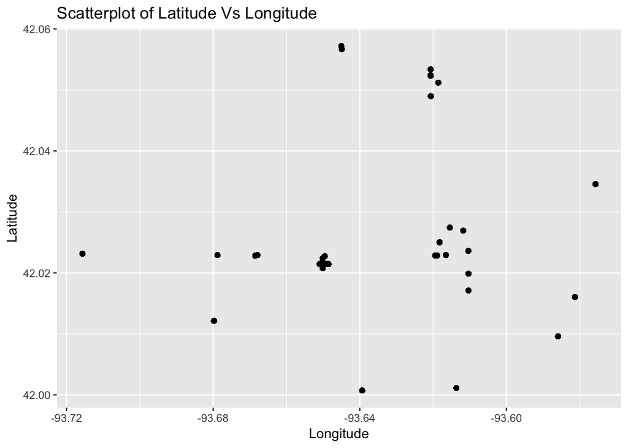

```r
library(ggplot2)
library(plotly)
data_clean_3 %>% ggplot(aes(x = long, y = lat))+
  geom_point(na.rm = TRUE) + geom_jitter(na.rm = TRUE)+
  ggtitle("Scatterplot of Latitude Vs Longitude")+ xlab("Longitude")+ ylab("Latitude")
```

2. Provide a visual breakdown of the liquor category (by Category Name). Include volume sold in the breakdown.

[figure not shown]

```r
data_clean_x <-  data_clean_3 %>% group_by(`Category Name`) %>% summarise(total_amount_of_alcohal_sold = (sum(`Volume Sold (Gallons)`))) %>% filter(total_amount_of_alcohal_sold >= 20000)

#summary(data_clean_x$total_amount_of_alcohal_sold)

data_clean_3 %>% ggplot(aes(x = `Category Name`, y = `Volume Sold (Liters)`))+
  geom_line(aes(color = `Category Name`))+ theme(legend.position = "none", axis.text.x = element_text(angle = 45))+ coord_flip()+
  ggtitle("Amount of Alcohol Sold by Brand Name")+ xlab("Brand Name")+ ylab("Amount in Liters Sold") # Complete breakdown
```

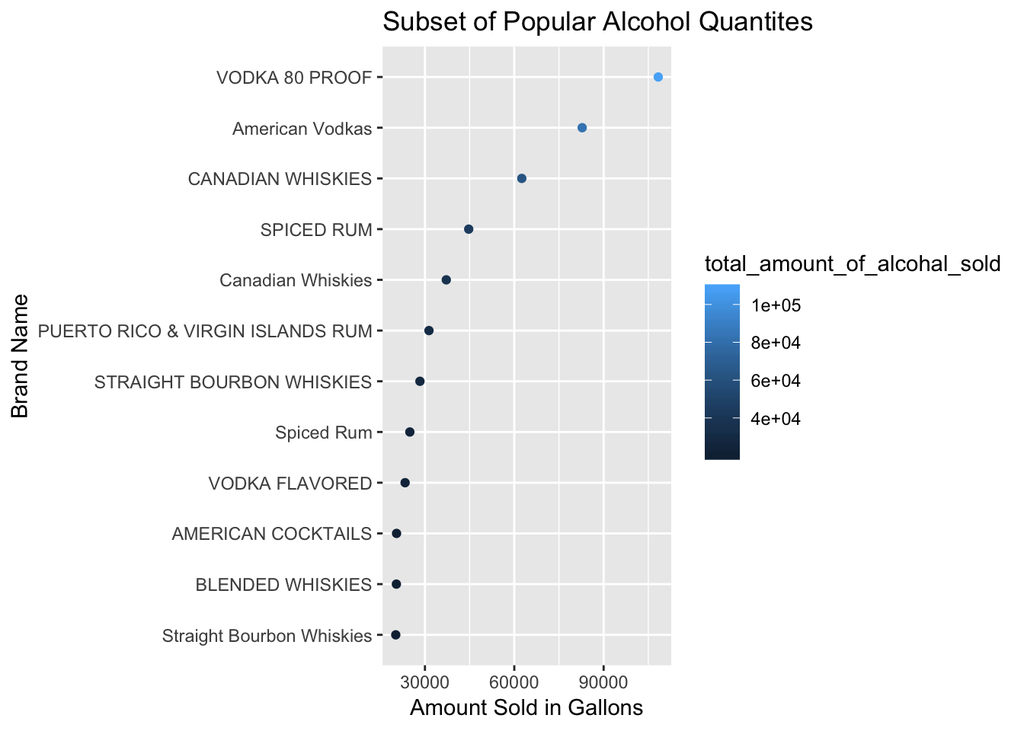

```r
data_clean_x %>% ggplot(aes(x = reorder(`Category Name`, total_amount_of_alcohal_sold), y = total_amount_of_alcohal_sold))+ geom_point(aes(color = total_amount_of_alcohal_sold))+ coord_flip()+
  ggtitle("Subset of Popular Alcohol Quantites")+ xlab("Brand Name")+ ylab("Amount Sold in Gallons") # Subset of volume sold.
```